[figure not shown]

LU(STI)-2

General Description

LUBRICATION

1. General Description

A: SPECIFICATION

Lubrication method Forced lubrication

Oil pump

Pump type Trochoid type

Number of teeth

Inner rotor 9

Outer rotor 10

Outer rotor diameter × Thickness mm (in) 78 × 11 (3.07 × 0.43)

Tip clearance between inner and outer

rotors

mm (in) Standard 0.04 — 0.14 (0.0016 — 0.0055)

Case clearance between outer rotor and

pump case

mm (in) Standard 0.10 — 0.175 (0.0039 — 0.0069)

Side clearance between inner rotor and

pump case

mm (in) Standard 0.02 — 0.07 (0.0008 — 0.0028)

Relief valve spring

Free length mm (in) 73.7 (2.902)

Installed length mm (in) 54.7 (2.154)

Load when installed N (kgf, lbf) 93.1 (9.49, 20.93)

Performance

(Oil temperature 80°C

(176°F))

600 rpm

Discharge

pressure

kPa (kg/cm

2

, psi) 98 (1.0, 14)

Discharge

rate

L (US qt, Imp qt)/min 6.4 (6.8, 5.6) or more

6,000 rpm

Discharge

pressure

kPa (kg/cm

2

, psi) 392 (4.0, 56.8)

Discharge

rate

L (US qt, Imp qt)/min 63.0 (66.6, 55.4) or more

Relief valve working pressure kPa (kg/cm

2

, psi) 538 (5.5, 78)

Oil filter

Filter type Full-flow filter type

Filtration area cm

2

(sq in)

Outer diameter: 68 mm (2.68 in) (black) 800 (124)

Outer diameter: 67.4 mm (2.65 in) (blue) 555 (86)

By-pass valve opening pressure kPa (kg/cm

2

, psi) 160 (1.63, 23.2)

Outer diameter ×

Width

mm (in)

Outer diameter: 68 mm (2.68 in) (black) 68 × 65 (2.68 × 2.56)

Outer diameter: 67.4 mm (2.65 in) (blue) 67.4 × 65.3 (2.65 × 2.57)

Installation screw specifications M 20 × 1.5

Oil pressure

switch

Typ e Immersed contact point type

Operating voltage — power consumption 12 V — 3.4 W or less

Warning light operating pressure kPa (kg/cm

2

, psi) 14.7 (0.15, 2.1)

Proof pressure kPa (kg/cm

2

, psi) 981 (10, 142) or more

Engine oil

Total capacity (at overhaul) L (US qt, Imp qt) 5.0 (5.3, 4.4)

When replacing engine oil and oil filter L (US qt, Imp qt) 4.3 (4.5, 3.8)

When replacing engine oil only L (US qt, Imp qt) 4.0 (4.2, 3.5)

[figure not shown]

LU(STI)-3

General Description

LUBRICATION

Specified oil:

CAUTION:

• Use 5W-30 (synthetic oil).

• It is acceptable to fill an engine with oil of another brand when replacing the oil, but make sure to

use the following engine oil specified by Subaru.

NOTE:

The proper viscosity oil helps the engine maintain its ideal temperature, and cranking speed increased by re-

Engine oil standard SAE viscosity No.

Those with the API standard SN

“Resource Conserving” or SM

“Energy Conserving” logo.

or

Those with the ILSAC standard GF-4

or GF-5 “starburst mark” displayed on

top of the container.

5W-30 (synthetic oil)

RM-00081

FOR

GASOLINE

ENGINES

RM-00002

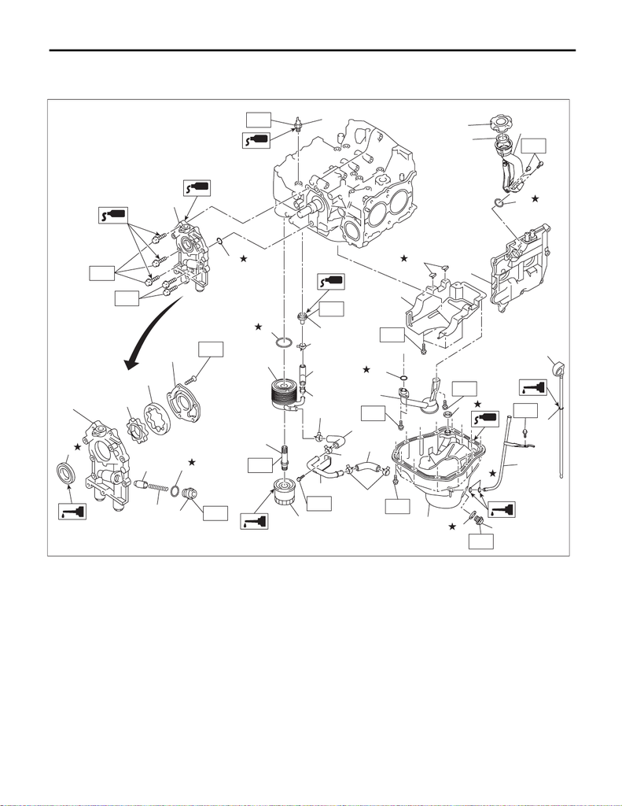

LU(STI)-4

General Description

LUBRICATION

B: COMPONENT

1. OIL PUMP AND OIL PAN

(15)

(14)

T5

T3

T2

T6

(9)

(8)

(7)

(6)

(16)

(26)

(5)

(4)

(3)

(2)

(1)

(19)

T9

(11)

(10)

(28)

(25)

(27)

(23)

T1

T3

(24)

(32)

T3

(20)

(31)

T4

(22)

(21)

T3

(18)

(17)

(30)

(33)

T3

(34)

T3

(35)

LU-03184

T7

(38)

(39)

(37)

(29)

(13)

(12)

T3

(37)

(36)

(37)

(37)

(37)

T8

[figure not shown]

LU(STI)-5

General Description

LUBRICATION

(1) Plug (19) Rocker cover (37) Clip

(2) Gasket (20) Baffle plate (38) Oil cooler hose B

(3) Relief valve spring (21) O-ring (39) Oil cooler hose C

(4) Relief valve (22) Oil strainer

(5) Front oil seal (23) Gasket Tightening torque: N·m (kgf-m, ft-lb)

(6) Oil pump case (24) Oil level gauge guide T1: 5 (0.5, 3.7)

(7) Inner rotor (25) Oil pan T2: 5.4 (0.6, 4.0)

(8) Outer rotor (26) Oil level gauge T3: 6.4 (0.7, 4.7)

(10) Oil filter (28) Drain plug T5: 25 (2.5, 18.4)

(11) Oil cooler connector (29) Gasket T6: 44 (4.5, 32.5)

(12) Oil cooler pipe (30) Oil filler cap T7: 46.5 (4.7, 34.3)

(13) Oil cooler (31) Seal T8: 54 (5.5, 39.8)

(14) O-ring (32) O-ring T9: 69 (7.0, 50.9)

(15) Oil pump ASSY (33) Gasket

(16) Oil pressure switch (34) O-ring

(17) Oil filler duct (35) Nipple

(18) O-ring (36) Oil cooler hose A

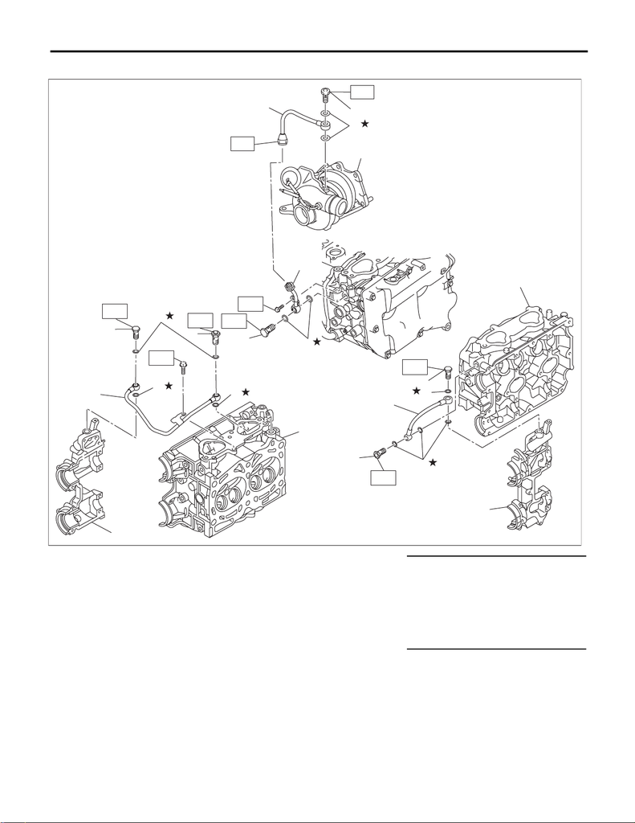

LU(STI)-6

General Description

LUBRICATION

2. OIL PIPE

(1) Oil inlet pipe (8) Cylinder head RH Tightening torque: N·m (kgf-m, ft-lb)

(2) Turbocharger oil pipe (9) Cylinder head LH T1: 6.4 (0.7, 4.7)

(3) Oil pipe RH (10) Front camshaft cap RH T2: 16 (1.6, 11.8)

(4) Union bolt with filter (with protru-

sion)

(11) Front camshaft cap LH T3: 20 (2.0, 14.8)

(5) Union bolt without filter (without

protrusion)

(12) Turbocharger T4: 29 (3.0, 21.4)

(6) Gasket (13) Union bolt without filter (with pro-

trusion)

(7) Oil pipe LH

LU-02727

(3)

(4)

(5)

(10)

T1

T4

T4

(4)

(5)

(11)

T4

T4

(2)

(5)

T1

T4

(1)

(13)

(12)

T2

T3

(6)

(6)

(6)

(6)

(6)

(6)

(6)

(7)

(8)

(9)

[figure not shown]

LU(STI)-7

General Description

LUBRICATION

C: CAUTION

• Prior to starting work, pay special attention to the following:

1. Always wear work clothes, a work cap, and protective shoes. Additionally, wear a helmet, protective

goggles, etc. if necessary.

2. Protect the vehicle using a seat cover, fender cover, etc.

3. Prepare the service tools, clean cloth, containers to catch grease and oil, etc.

• Prepare a container and cloth when performing work which oil possibly spills. If oil spills, wipe it off imme-

diately to prevent from penetrating into floor or flowing out for environmental protection.

• Vehicle components are extremely hot immediately after driving. Be wary of receiving burns from heated

parts.

• When performing a repair, identify the cause of trouble and avoid unnecessary removal, disassembly and

replacement.

• Before disconnecting connectors of sensors or units, be sure to disconnect the ground cable from battery.

• Always use the jack-up point when the shop jacks or rigid racks are used to support the vehicle.

• Remove contamination including dirt and corrosion before removal, installation, disassembly or assembly.

• Keep the removed parts in order and protect them from dust and dirt.

• All removed parts, if to be reused, should be reinstalled in the original positions with attention to the correct

directions, etc.

• Bolts, nuts and washers should be replaced with new parts as required.

• Be sure to tighten the fasteners including bolts and nuts to the specified torque.

• If the engine oil is spilt over exhaust pipe or the under cover, wipe it off with cloth to avoid emitting smoke

or causing a fire.

• Follow all government and local regulations concerning disposal of refuse when disposing of oil.

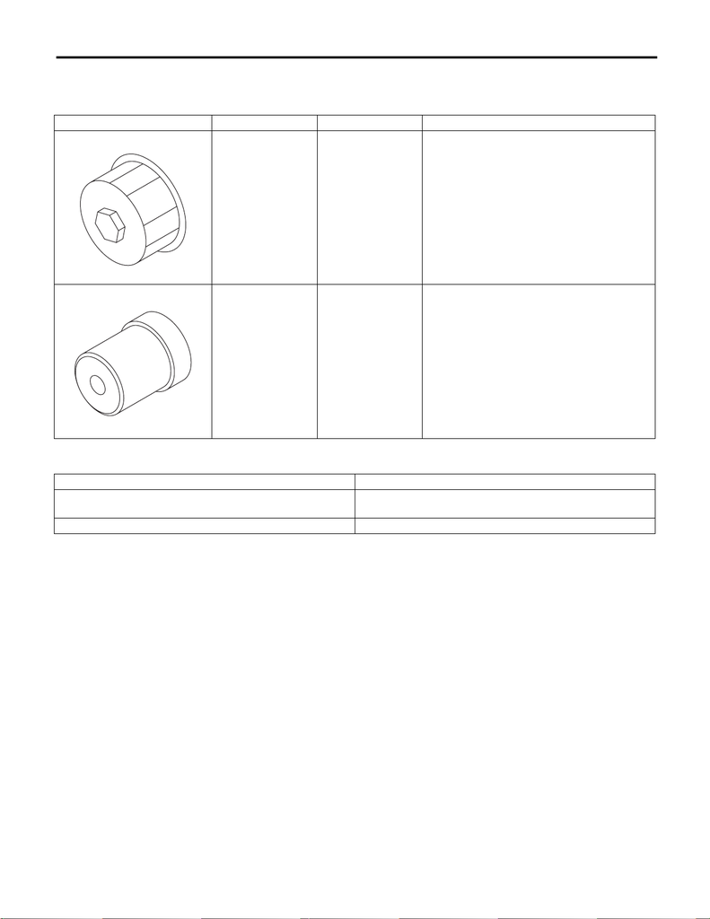

LU(STI)-8

General Description

LUBRICATION

D: PREPARATION TOOL

1. SPECIAL TOOL

2. GENERAL TOOL

ILLUSTRATION TOOL NUMBER DESCRIPTION REMARKS

18332AA000 OIL FILTER

WRENCH

Used for removing and installing oil filter (black).

(Outer diameter: 68 mm (2.68 in))

499587100 OIL SEAL

INSTALLER

Used for installing oil seal into oil pump.

TOOL NAME REMARKS

Oil filter wrench (65/67 mm 14 Flutes) Used for removing and installing oil filter (blue). (Outer diame-

ter: 67.4 mm (2.65 in))

Circuit tester Used for measuring resistance and voltage.

ST18332AA000

ST-499587100